# Neuropsych analysis using stripped files

There isn’t much cleaning to do for neuropsych. Assuming the data is good, we can try to clip based on date difference later:

```r
source('~/ncr_notebooks/baseline_prediction/src/aux_functions.R')
beery_data = read.csv('~/data/baseline_prediction/stripped/beeryVMI.csv')
gf_fname = '~/data/baseline_prediction/stripped/clinical.csv'
gf = read.csv(gf_fname)
gf = gf[gf$BASELINE=='BASELINE', ]
my_ids = intersect(gf$MRN, beery_data$Medical.Record...MRN)
mbeery = mergeOnClosestDate(gf, beery_data, my_ids, y.date='record.date.collected', y.id='Medical.Record...MRN')
```

Finally, let’s remove anyone with difference between clinical and neuropsych that’s too big:

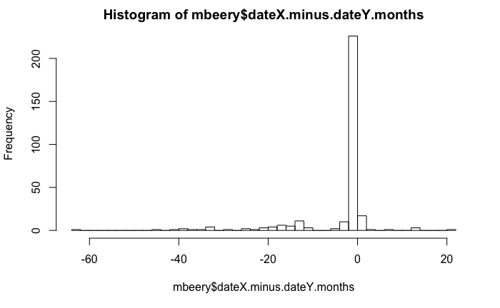

```r
nbreaks = 40
hist(mbeery$dateX.minus.dateY.months, breaks=nbreaks)
```

There is a big spread. Let’s err in the side of caution and cap it to 1 year before or after:

```r
rm_me = abs(mbeery$dateX.minus.dateY.months) > 12
print(sprintf('Reducing from %d to %d tests', nrow(mbeery), nrow(mbeery)-sum(rm_me)))
```

```
[1] "Reducing from 308 to 260 tests"
```

```r
mbeery = mbeery[!rm_me, ]
mbeery$dateClinical.minus.dateBeery.months = mbeery$dateX.minus.dateY.months
mbeery$dateX.minus.dateY.months = NULL
```

With Beery incorporated, let’s add other neuropsych:

```r
cpt_data = read.csv('~/data/baseline_prediction/stripped/cpt.csv')
my_ids = intersect(gf$MRN, cpt_data$MRN)
mcpt = mergeOnClosestDate(gf, cpt_data, my_ids)
rm_me = abs(mcpt$dateX.minus.dateY.months) > 12
print(sprintf('Reducing from %d to %d tests', nrow(mcpt), nrow(mcpt)-sum(rm_me)))
```

```
[1] "Reducing from 290 to 195 tests"
```

```r
mcpt = mcpt[!rm_me, ]
mcpt$dateClinical.minus.dateCPT.months = mcpt$dateX.minus.dateY.months
mcpt$dateX.minus.dateY.months = NULL
```

```r
iq_data = read.csv('~/data/baseline_prediction/stripped/iq.csv')
my_ids = intersect(gf$MRN, iq_data$Medical.Record...MRN)
miq = mergeOnClosestDate(gf, iq_data, my_ids, y.id='Medical.Record...MRN', y.date='record.date.collected')
rm_me = abs(miq$dateX.minus.dateY.months) > 12
print(sprintf('Reducing from %d to %d tests', nrow(miq), nrow(miq)-sum(rm_me)))
```

```
[1] "Reducing from 304 to 251 tests"
```

```r
miq = miq[!rm_me, ]
miq$dateClinical.minus.dateIQ.months = miq$dateX.minus.dateY.months
miq$dateX.minus.dateY.months = NULL
```

```r
wisc_data = read.csv('~/data/baseline_prediction/stripped/wisc.csv')
my_ids = intersect(gf$MRN, wisc_data$Medical.Record...MRN)
mwisc = mergeOnClosestDate(gf, wisc_data, my_ids, y.id='Medical.Record...MRN', y.date='record.date.collected')
rm_me = abs(mwisc$dateX.minus.dateY.months) > 12
print(sprintf('Reducing from %d to %d tests', nrow(mwisc), nrow(mwisc)-sum(rm_me)))
```

```
[1] "Reducing from 308 to 245 tests"
```

```r
mwisc = mwisc[!rm_me, ]
mwisc$dateClinical.minus.dateWISC.months = mwisc$dateX.minus.dateY.months
mwisc$dateX.minus.dateY.months = NULL
```

```r
wj_data = read.csv('~/data/baseline_prediction/stripped/wj.csv')
my_ids = intersect(gf$MRN, wj_data$Medical.Record...MRN)
mwj = mergeOnClosestDate(gf, wj_data, my_ids, y.id='Medical.Record...MRN', y.date='record.date.collected')
rm_me = abs(mwj$dateX.minus.dateY.months) > 12
print(sprintf('Reducing from %d to %d tests', nrow(mwj), nrow(mwj)-sum(rm_me)))
```

```
[1] "Reducing from 313 to 279 tests"
```

```r
mwj = mwj[!rm_me, ]
mwj$dateClinical.minus.dateWJ.months = mwj$dateX.minus.dateY.months
mwj$dateX.minus.dateY.months = NULL
```

Finally, we merge across neuropsych tests based on MRN. Let’s go from most rows to least rows:

```r
merged = merge(mwj, mbeery, by='MRN')
merged = merge(merged, miq, by='MRN')
merged = merge(merged, mwisc, by='MRN')
```

[output not shown]

```r
merged = merge(merged, mcpt, by='MRN')
```

[output not shown]

Ready for some ML. Let’s get all features first, and try some NV vs ADHD classification, clumping in the ADHD_NOS folks.

```r
library(caret)
library(randomForest)
seed = 107
# I'm selecting mostly raw or standard scores depending on NAs
phen_vars = c('FSIQ',
              # CPT
              'N_of_omissions', 'N_commissions', 'hit_RT', 'hit_RT_SE', 'variability_of_SE', 'N_perservations',
              'hit_RT_block_change', 'hit_RT_SE_block_change', 'hit_RT_ISI_change', 'hit_RT_SE_ISI_change',
              # WISC
              'Raw.score..DSF', 'Raw.score..DSB', 'Raw.score..SSF', 'Raw.score..SSB',
              # WJ
              'PS',
              # Beery
              'Standard.score'
              )
keep_me = c()
for (v in phen_vars) {
  keep_me = c(keep_me, which(colnames(merged) == v))
}
X = merged[, keep_me]
y = merged$DX_BASELINE
y[y != 'NV'] = 'ADHD'
y = factor(y, levels = c('NV', 'ADHD'))
```

Before we do some ML, we need to clean up the NAs. For now, I’ll just remove the subjects:

```r
rm_me = rowSums(is.na(X)) > 0
X = X[!rm_me, ]
y = y[!rm_me]
```

Let’s do some ML:

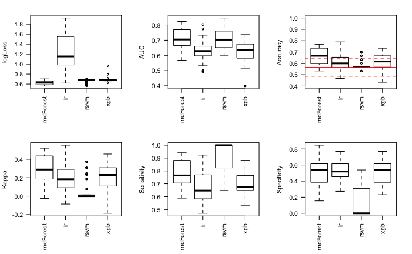

```r
# ldata = X
# groups = y
root_fname = '~/data/baseline_prediction/results/stripped_neuropsych_NVvsADHD'
# save(ldata, groups, file=sprintf('%s.RData', root_fname), compress=T)
#runInCluster(root_fname, train_test_ratio=.8, cpuDiff=2, run_models=c('rndForest', 'lr', 'rsvm', 'xgb'))
do_metrics_plots(root_fname)
```

Let’s try to improve this a bit. First, let’s study the rf model a bit more:

```r
set.seed(107)
split <- createDataPartition(y, p = .8, list = FALSE)
Xtrain <- X[ split, ]
Xtest  <- X[-split, ]
ytrain = y[split]
ytest = y[-split]
library(doMC)
library(caret)
registerDoMC(7)
## create the cross-validation files as a list to use with different
## functions
set.seed(107)
index <- createMultiFolds(ytrain, times = 5)
fiveStats <- function(...) c(twoClassSummary(...), defaultSummary(...))
fullCtrl <- trainControl(method = "repeatedcv",
                         repeats = 5,
                         summaryFunction = fiveStats,
                         classProbs = TRUE,
                         index = index)
rfFull <- train(Xtrain, ytrain,
                method = "rf",
                metric = "ROC",
                tuneGrid = data.frame(mtry = floor(sqrt(length(predVars)))),
                ntree = 1000,
                trControl = fullCtrl)
rfFull
```

[output not shown]

OK, right at the median accuracy from above, and a bit below AUC. Let’s tune it a bit:

```r
ctrl <- rfeControl(method = "repeatedcv", repeats = 5,
                   saveDetails = TRUE,
                   index = index,
                   returnResamp = "final")
ctrl$functions <- rfFuncs
ctrl$functions$summary <- fiveStats
varSeq <- seq(1, ncol(X), by = 1)
set.seed(107)
rfRFE <- rfe(Xtrain, ytrain,
             sizes = varSeq,
             metric = "ROC",
             ntree = 1000,
             rfeControl = ctrl)
rfRFE
```

```
Recursive feature selection

Outer resampling method: Cross-Validated (10 fold, repeated 5 times)

Resampling performance over subset size:

 Variables    ROC   Sens   Spec Accuracy   Kappa  ROCSD SensSD SpecSD AccuracySD KappaSD Selected
         1 0.6031 0.6343 0.4347   0.5472 0.06764 0.1586 0.1982 0.2542     0.1340  0.2742
         2 0.6110 0.6514 0.4527   0.5632 0.10358 0.1419 0.1940 0.2325     0.1293  0.2617
         3 0.6058 0.6886 0.4700   0.5922 0.16033 0.1489 0.1841 0.2046     0.1063  0.2147
         4 0.5983 0.6686 0.4807   0.5858 0.14975 0.1648 0.1644 0.2071     0.1119  0.2270
         5 0.6161 0.6829 0.4993   0.6017 0.18242 0.1684 0.1786 0.2310     0.1362  0.2785
         6 0.6304 0.7171 0.4873   0.6164 0.20574 0.1620 0.1859 0.2500     0.1565  0.3237
         7 0.6446 0.7371 0.4713   0.6212 0.21025 0.1617 0.1510 0.2348     0.1351  0.2868
         8 0.6556 0.7429 0.4940   0.6342 0.23990 0.1574 0.1658 0.2295     0.1235  0.2597
         9 0.6794 0.7486 0.5480   0.6610 0.29883 0.1321 0.1621 0.2203     0.1273  0.2677
        10 0.6937 0.7800 0.5547   0.6823 0.34057 0.1319 0.1560 0.1908     0.1161  0.2406
        11 0.7079 0.7714 0.5607   0.6795 0.33611 0.1335 0.1500 0.2026     0.1178  0.2453
        12 0.7080 0.7714 0.5673   0.6826 0.34307 0.1418 0.1554 0.1979     0.1162  0.2402
        13 0.7110 0.7714 0.5533   0.6760 0.32968 0.1421 0.1633 0.1983     0.1163  0.2376        *
        14 0.7026 0.7914 0.5153   0.6712 0.31156 0.1380 0.1612 0.2337     0.1248  0.2660
        15 0.6980 0.7886 0.5233   0.6729 0.31829 0.1441 0.1664 0.2106     0.1309  0.2721
        16 0.6842 0.7829 0.5367   0.6759 0.32405 0.1438 0.1561 0.2212     0.1272  0.2683
        17 0.6906 0.7829 0.5160   0.6667 0.30381 0.1433 0.1664 0.2261     0.1296  0.2730

The top 5 variables (out of 13):
   Standard.score, PS, hit_RT, Raw.score..SSB, variability_of_SE
```

We might need to do a more in-depth study of these neuropsych variables. Let’s copy the example from https://raw.githubusercontent.com/cran/AppliedPredictiveModeling/master/inst/chapters/19_Feature_Select.R:

```r
sbfResamp <- function(x, fun = mean)
{
  x <- unlist(lapply(x$variables, length))
  fun(x)
}
sbfROC <- function(mod) auc(roc(testing$Class, predict(mod, testing)$Impaired))
pScore <- function(x, y)
{
  numX <- length(unique(x))
  if(numX > 2)
  {
    out <- t.test(x ~ y)$p.value
  } else {
    out <- fisher.test(factor(x), y)$p.value
  }
  out
}
ldaWithPvalues <- ldaSBF
ldaWithPvalues$score <- pScore
ldaWithPvalues$summary <- fiveStats
ldaWithPvalues$filter <- function (score, x, y)
{
  keepers <- score <= 0.05
  keepers
}
sbfCtrl <- sbfControl(method = "repeatedcv",
                      repeats = 5,
                      verbose = TRUE,
                      functions = ldaWithPvalues,
                      index = index)
rawCorr <- sbf(training[, predVars],
               training$Class,
               tol = 1.0e-12,
               sbfControl = sbfCtrl)
rawCorr
```

```
Selection By Filter

Outer resampling method: Cross-Validated (10 fold, repeated 5 times)

Resampling performance:

    ROC   Sens   Spec Accuracy  Kappa  ROCSD SensSD SpecSD AccuracySD KappaSD
 0.7302 0.5387 0.7429   0.6546 0.2877 0.1349 0.1964 0.1893     0.1407  0.2866

Using the training set, 9 variables were selected:
   hit_RT_SE, variability_of_SE, N_perservations, hit_RT_ISI_change, hit_RT_SE_ISI_change...

During resampling, the top 5 selected variables (out of a possible 10):
   hit_RT_SE_ISI_change (100%), PS (100%), Standard.score (100%), variability_of_SE (100%), Raw.score..SSB (98%)

On average, 8 variables were selected (min = 5, max = 10)
```

```r
ldaWithPvalues$filter <- function (score, x, y)
{
  score <- p.adjust(score,  "bonferroni")
  keepers <- score <= 0.05
  keepers
}
sbfCtrl <- sbfControl(method = "repeatedcv",
                      repeats = 5,
                      verbose = TRUE,
                      functions = ldaWithPvalues,
                      index = index)
adjCorr <- sbf(training[, predVars],
               training$Class,
               tol = 1.0e-12,
               sbfControl = sbfCtrl)
adjCorr
```

```
Selection By Filter

Outer resampling method: Cross-Validated (10 fold, repeated 5 times)

Resampling performance:

    ROC   Sens Spec Accuracy  Kappa  ROCSD SensSD SpecSD AccuracySD KappaSD
 0.7219 0.4873  0.7   0.6079 0.1921 0.1184 0.1644 0.1738      0.116  0.2352

Using the training set, 5 variables were selected:
   variability_of_SE, hit_RT_SE_ISI_change, Raw.score..SSB, PS, Standard.score.

During resampling, the top 5 selected variables (out of a possible 8):
   Standard.score (100%), PS (98%), hit_RT_SE_ISI_change (70%), variability_of_SE (38%), Raw.score..SSB (30%)

On average, 3.4 variables were selected (min = 1, max = 8)
```

```r
ldaWithPvalues$filter <- function (score, x, y)
{
  keepers <- score <= 0.05
  corrMat <- cor(x[,keepers])
  tooHigh <- findCorrelation(corrMat, .75)
  if(length(tooHigh) > 0) keepers[tooHigh] <- FALSE
  keepers
}
sbfCtrl <- sbfControl(method = "repeatedcv",
                      repeats = 5,
                      verbose = TRUE,
                      functions = ldaWithPvalues,
                      index = index)
rawNoCorr <- sbf(training[, predVars],
                 training$Class,
                 tol = 1.0e-12,
                 sbfControl = sbfCtrl)
rawNoCorr
```

```
Selection By Filter

Outer resampling method: Cross-Validated (10 fold, repeated 5 times)

Resampling performance:

    ROC  Sens   Spec Accuracy  Kappa  ROCSD SensSD SpecSD AccuracySD KappaSD
 0.7265 0.524 0.7429   0.6482 0.2726 0.1369 0.2122 0.1893     0.1461  0.3008

Using the training set, 9 variables were selected:
   hit_RT_SE, variability_of_SE, N_perservations, hit_RT_ISI_change, hit_RT_SE_ISI_change...

During resampling, the top 5 selected variables (out of a possible 10):
   hit_RT_SE_ISI_change (100%), PS (100%), Standard.score (100%), variability_of_SE (100%), Raw.score..SSB (98%)

On average, 7.9 variables were selected (min = 5, max = 9)
```

```r
ldaWithPvalues$filter <- function (score, x, y)
{
  score <- p.adjust(score,  "bonferroni")
  keepers <- score <= 0.05
  corrMat <- cor(x[,keepers])
  tooHigh <- findCorrelation(corrMat, .75)
  if(length(tooHigh) > 0) keepers[tooHigh] <- FALSE
  keepers
}
sbfCtrl <- sbfControl(method = "repeatedcv",
                      repeats = 5,
                      verbose = TRUE,
                      functions = ldaWithPvalues,
                      index = index)
adjNoCorr <- sbf(training[, predVars],
                 training$Class,
                 tol = 1.0e-12,
                 sbfControl = sbfCtrl)
```

```
Error in { :
  task 37 failed - "supply both 'x' and 'y' or a matrix-like 'x'"
```